# Math 189 Homework 2

Yunchun Pan, Siqing Lyu, Nathan Ng, Pudan Xu

1/8/2021

## Introduction

- we will examine the Motor Trend Car Road Tests dataset (available from GitHub). The file contains data extracted from the 1974 Motor Trend US magazine, and comprises fuel consumption and 10 aspects of automobile design and performance for 32 automobiles (1973–74 models)
- The following variables were measured:
1. **mpg**: Miles per gallon
2. **cyl**: Number of cylinders
3. **disp**
4. **hp**
5. **drat**
6. **wt**: Weight
7. **qsec**
8. **vs**
9. **am**
10. **gear**
11. **carb**

## Our Work

We first load the Motor Trend Car Road Tests dataset into R to get the data we use throughout this assignment.

```r
mtcars <- read.csv("C:/Users/lyusi/Downloads/ma189-main/Data/mtcars.csv")
```

After we load in our dataset, we Calculate sample mean and sample variance of each variable and store them into matrices to be $M_m$ and $M_{v}$ respectively.

```r
ncols = dim(mtcars)[2]
varMean <- colMeans(mtcars[,2:ncols])
Mm <-t(as.matrix(varMean))
Mm <- Mm[1,]
Mm
```

```
       mpg        cyl       disp         hp       drat         wt       qsec         vs         am       gear
 20.090625   6.187500 230.721875 146.687500   3.596563   3.217250  17.848750   0.437500   0.406250   3.687500
      carb
  2.812500
```

```r
Mv <- Mm
for (i in 2:dim(mtcars)[2]) {
  Mv[i-1] = var(mtcars[,i])
}
Mv
```

```
          mpg           cyl          disp            hp          drat            wt          qsec            vs
   36.3241028     3.1895161 15360.7998286  4700.8669355     0.2858814     0.9573790     3.1931661     0.2540323
           am          gear          carb
    0.2489919     0.5443548     2.6088710
```

```r
varCov <- var(mtcars[,2:ncols])
varCov
```

```
             mpg         cyl        disp          hp         drat          wt         qsec           vs
mpg    36.324103  -9.1723790  -633.09721 -320.732056   2.19506351  -5.1166847   4.50914919   2.01713710
cyl    -9.172379   3.1895161   199.66028  101.931452  -0.66836694   1.3673710  -1.88685484  -0.72983871
disp -633.097208 199.6602823 15360.79983 6721.158669 -47.06401915 107.6842040 -96.05168145 -44.37762097
hp   -320.732056 101.9314516  6721.15867 4700.866935 -16.45110887  44.1926613 -86.77008065 -24.98790323
drat    2.195064  -0.6683669   -47.06402  -16.451109   0.28588135  -0.3727207   0.08714073   0.11864919
wt     -5.116685   1.3673710   107.68420   44.192661  -0.37272073   0.9573790  -0.30548161  -0.27366129
qsec    4.509149  -1.8868548   -96.05168  -86.770081   0.08714073  -0.3054816   3.19316613   0.67056452
vs      2.017137  -0.7298387   -44.37762  -24.987903   0.11864919  -0.2736613   0.67056452   0.25403226
am      1.803931  -0.4657258   -36.56401   -8.320565   0.19015121  -0.3381048  -0.20495968   0.04233871
gear    2.135685  -0.6491935   -50.80262   -6.358871   0.27598790  -0.4210806  -0.28040323   0.07661290
carb   -5.363105   1.5201613    79.06875   83.036290  -0.07840726   0.6757903  -1.89411290  -0.46370968
               am        gear        carb
mpg    1.80393145   2.1356855 -5.36310484
cyl   -0.46572581  -0.6491935  1.52016129
disp -36.56401210 -50.8026210 79.06875000
hp    -8.32056452  -6.3588710 83.03629032
drat   0.19015121   0.2759879 -0.07840726
wt    -0.33810484  -0.4210806  0.67579032
qsec  -0.20495968  -0.2804032 -1.89411290
vs     0.04233871   0.0766129 -0.46370968
am     0.24899194   0.2923387  0.04637097
gear   0.29233871   0.5443548  0.32661290
carb   0.04637097   0.3266129  2.60887097
```

```r
corre <- cor(mtcars[,2:ncols])
corre
```

```
            mpg        cyl       disp         hp        drat         wt        qsec         vs          am
mpg   1.0000000 -0.8521620 -0.8475514 -0.7761684  0.68117191 -0.8676594  0.41868403  0.6640389  0.59983243
cyl  -0.8521620  1.0000000  0.9020329  0.8324475 -0.69993811  0.7824958 -0.59124207 -0.8108118 -0.52260705
disp -0.8475514  0.9020329  1.0000000  0.7909486 -0.71021393  0.8879799 -0.43369788 -0.7104159 -0.59122704
hp   -0.7761684  0.8324475  0.7909486  1.0000000 -0.44875912  0.6587479 -0.70822339 -0.7230967 -0.24320426
drat  0.6811719 -0.6999381 -0.7102139 -0.4487591  1.00000000 -0.7124406  0.09120476  0.4402785  0.71271113
wt   -0.8676594  0.7824958  0.8879799  0.6587479 -0.71244065  1.0000000 -0.17471588 -0.5549157 -0.69249526
qsec  0.4186840 -0.5912421 -0.4336979 -0.7082234  0.09120476 -0.1747159  1.00000000  0.7445354 -0.22986086
vs    0.6640389 -0.8108118 -0.7104159 -0.7230967  0.44027846 -0.5549157  0.74453544  1.0000000  0.16834512
am    0.5998324 -0.5226070 -0.5912270 -0.2432043  0.71271113 -0.6924953 -0.22986086  0.1683451  1.00000000
gear  0.4802848 -0.4926866 -0.5555692 -0.1257043  0.69961013 -0.5832870 -0.21268223  0.2060233  0.79405876
carb -0.5509251  0.5269883  0.3949769  0.7498125 -0.09078980  0.4276059 -0.65624923 -0.5696071  0.05753435
           gear        carb
mpg   0.4802848 -0.55092507
cyl  -0.4926866  0.52698829
disp -0.5555692  0.39497686
hp   -0.1257043  0.74981247
drat  0.6996101 -0.09078980
wt   -0.5832870  0.42760594
qsec -0.2126822 -0.65624923
vs    0.2060233 -0.56960714
am    0.7940588  0.05753435
gear  1.0000000  0.27407284
carb  0.2740728  1.00000000
```

Draw a scatter plot between wt (Weight) and mpg (Miles per gallon).

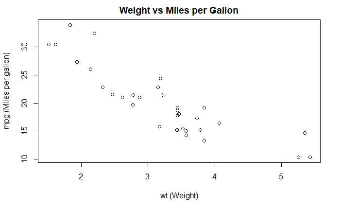

```r
plot(x = mtcars$wt, y = mtcars$mpg,
     xlab = "wt (Weight)", ylab = "mpg (Miles per gallon)",
     main = "Weight vs Miles per Gallon")
```

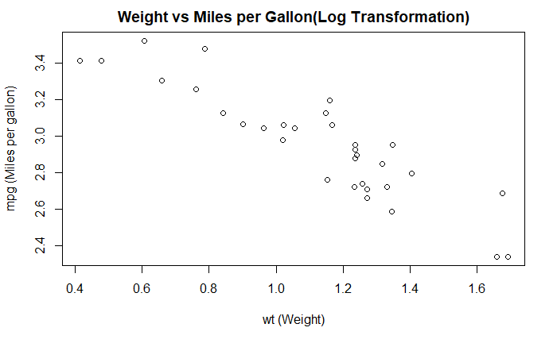

```r
x <- log(mtcars[,c("wt","mpg")])
plot(x[,1],x[,2],xlab = "wt (Weight)", ylab = "mpg (Miles per gallon)",
     main = "Weight vs Miles per Gallon(Log Transformation)")
```

Draw a scatter plot to show the relationship between wt (Weight), mpg (Miles per gallon) and cyl (Number of cylinders) using a 3D scatter plot

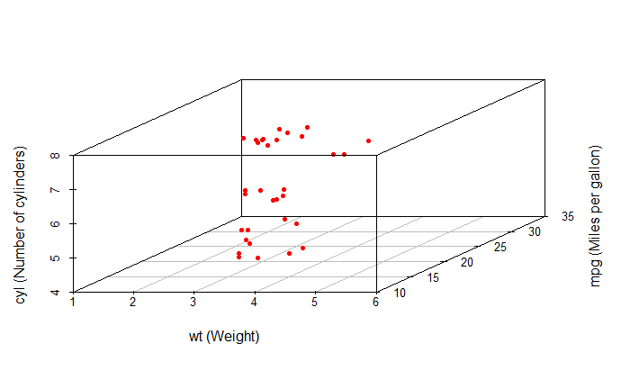

```r
library("scatterplot3d")
scatterplot3d(x = mtcars$wt, y = mtcars$mpg, z = mtcars$cyl,
              xlab = "wt (Weight)", ylab = "mpg (Miles per gallon)",    zlab = "cyl (Number of cylinders) ",
              color="red", pch=20)
```

Since it is hard to analyze the original 3D Scatter Plot, we would apply Log Transformation to better analyze the data

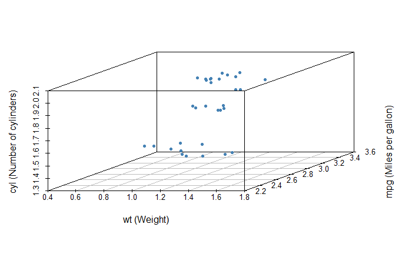

```r
scatterplot3d(x = log(mtcars$wt), y = log(mtcars$mpg), z = log(mtcars$cyl),
              xlab = "wt (Weight)", ylab = "mpg (Miles per gallon)",    zlab = "cyl (Number of cylinders) ",
              color="steelblue", pch=20)
```

Draw pairwise scatter plot for all variables.

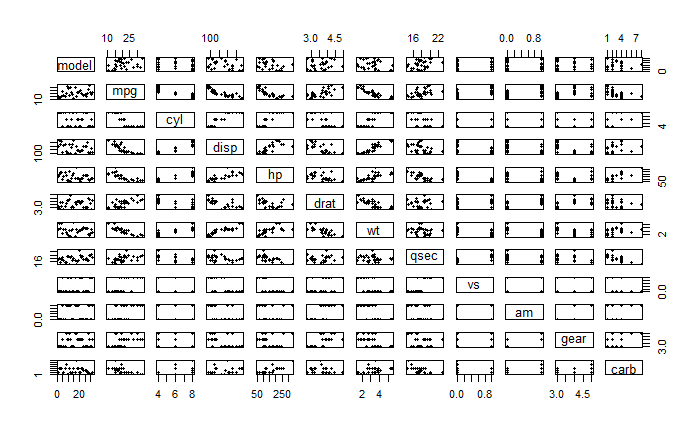

```r
pairs(mtcars, pch=20)
```